# Co-expression Networks · Hands-on

Tutorial VT1 | ISCB-Latin America SoIBio SPBBC Conference on Bioinformatics 2026

Author

Dr. Deisy Morselli Gysi | Federal University of Paraná (UFPR), Brazil

Published

November 9, 2026

Lithium has been used to treat bipolar disorder for more than 70 years, and we still do not fully understand what it does. In this notebook we follow one question from raw data to biology: **what does lithium change in how blood genes vary together, and can we tell that apart from the disease itself?**

The notebook follows the lecture step by step. Run the chunks in order in RStudio (or Positron). Each **Exercise** asks you to change one thing and look at what happens: fill the `___` blanks, run the chunk, and only then open **Show solution**.

**ImportantBefore you start · run it again**

1. Open the workshop folder as the working directory (it contains `data/`, `R/`, and `results/`).
2. Restore the pinned package environment **once**:

   ```r
   install.packages("renv")
   renv::restore()
   ```

3. The input `data/gse124326_bd_lithium.rds` ships with the workshop. If it is missing, rebuild it from GEO with `source("R/prepare_gse124326.R")`.
4. The wTO networks for 2,000 genes are **cached** in `results/wto_cache_2k.rds` and load in seconds. If the file is missing, rebuild it once (~15 min) with `source("R/build_wto_cache.R")`.
5. To render the whole notebook in one go, from a terminal in this folder:

   ```bash
   quarto render coexpression_handson_iscb_la_2026.qmd
   ```

Do not install or update packages during the workshop: update deliberately, review the results, then regenerate `renv.lock`.

# 1 Setup

```r
suppressPackageStartupMessages({
  library(dplyr)
  library(tidyr)
  library(tibble)
  library(ggplot2)
  library(WGCNA)
})
options(stringsAsFactors = FALSE)
source("R/wto_fast.R")   # vectorised wTO, identical output to wTO::wTO.fast()

pal <- list(bg = "#1A1618", rose = "#EEB4C8", teal = "#64D2D2", gold = "#F2C66D",
            muted = "#8B7780", text = "#D7CBD0", paper = "#F3E9ED",
            plum = "#A35876", dteal = "#318080", line = "#4A303A", soft = "#C0B4B8")

theme_set(theme_minimal(base_size = 13) + theme(
  text = element_text(color = "#E5DADA"),
  plot.title = element_text(face = "bold", color = pal$rose),
  plot.subtitle = element_text(color = pal$soft),
  plot.background = element_rect(fill = pal$bg, color = NA),
  panel.background = element_rect(fill = pal$bg, color = NA),
  panel.grid.minor = element_blank(),
  panel.grid.major = element_line(color = pal$line, linewidth = 0.35),
  axis.text = element_text(color = "#E5DADA"),
  axis.title = element_text(color = pal$soft),
  legend.position = "bottom",
  legend.background = element_rect(fill = pal$bg, color = NA),
  legend.key = element_rect(fill = pal$bg, color = NA)
))
grp_levels <- c("Control", "no Lithium", "Lithium")
cond_cols <- c(Control = pal$gold, `no Lithium` = pal$teal, Lithium = pal$rose)
```

# 2 Data and quality control

The data are whole-blood RNA-seq from **GSE124326** (Krebs *et al.*, 2020): 112 **controls** and 226 patients with bipolar I disorder, 152 taking **lithium** and 74 not taking it. Having three groups is what makes the story work later: links shared by both patient groups point to the disease, and links seen only on lithium point to the drug. The prepared file holds log2-CPM values (genes x samples) and one row of metadata per sample, including sex, sequencing plate, and estimated blood-cell fractions. Before any modelling, we look at what actually drives the data.

```r
course_data <- readRDS("data/gse124326_bd_lithium.rds")
expression_matrix <- course_data$expression   # genes x samples, log2-CPM
sample_info <- course_data$sample_info
stopifnot(identical(sample_info$sample, colnames(expression_matrix)))
dim(expression_matrix)
```

```
[1] 13013   338
```

```r
head(sample_info[, c("sample", "treatment", "sex", "plate", "neutrophils")])
```

```
     sample  treatment sex  plate neutrophils
107 11R0539    Lithium   F plate1   0.4675258
108 11R0540 no Lithium   M plate1   0.1931334
109 11R0541 no Lithium   M plate1   0.3715132
111 11R0545    Control   M plate3   0.3662477
112 11R0546 no Lithium   F plate1   0.2178519
113 11R0547    Lithium   F plate1   0.5034182
```

**TipExercise 1 · What drives the main axes of variation?**

Count the samples per condition and per sex. Run a PCA on the 500 most variable genes and colour it by **treatment**, **sex**, and **plate** in turn. Which variable lines up with PC1 or PC2?

```r
table(sample_info$treatment, sample_info$___)

raw_variance <- apply(expression_matrix, 1, var)
top500 <- names(sort(raw_variance, decreasing = TRUE))[1:___]
pca <- prcomp(t(expression_matrix[top500, ]), scale. = TRUE)
pca_data <- cbind(sample_info, PC1 = pca$x[, 1], PC2 = pca$x[, 2])
ggplot(pca_data, aes(PC1, PC2, color = ___)) + geom_point()
```

**NoteShow solution**

```r
table(sample_info$treatment, sample_info$sex)
```

```
              F  M
  Control    67 45
  Lithium    90 62
  no Lithium 35 39
```

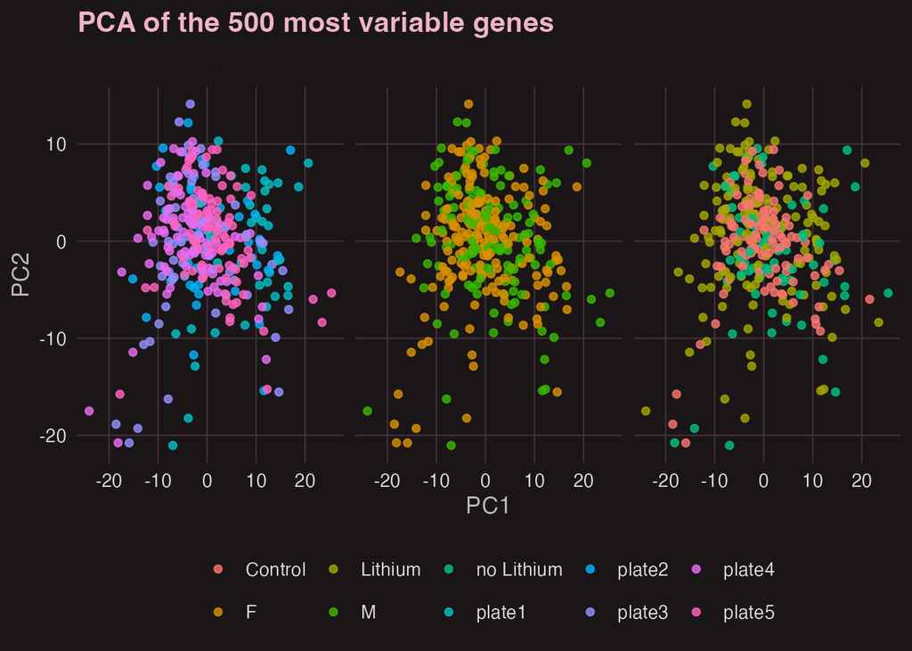

```r
raw_variance <- apply(expression_matrix, 1, var)
top500 <- names(sort(raw_variance, decreasing = TRUE))[1:500]
pca <- prcomp(t(expression_matrix[top500, ]), scale. = TRUE)
pca_data <- cbind(sample_info, PC1 = pca$x[, 1], PC2 = pca$x[, 2])
pca_long <- pca_data |>
  select(PC1, PC2, treatment, sex, plate) |>
  pivot_longer(c(treatment, sex, plate), names_to = "variable", values_to = "level")
ggplot(pca_long, aes(PC1, PC2, color = level)) +
  geom_point(size = 1.6, alpha = 0.8) +
  facet_wrap(~ variable) +
  labs(title = "PCA of the 500 most variable genes", color = NULL)
```

**Sequencing plate** drives PC1, the largest axis of variation. Sex barely shows on the first two PCs, even though `XIST` is the single most variable gene: one gene does not make a principal component. Lithium does **not** dominate the main axes either; its effect is real but small per gene. Plate and sex go into the limma model and are removed before building networks.

# 3 Gene selection

Exercise 1 showed that plate and sex are loud. Before building networks we decide which genes go in, and we keep those technical signals out. Network methods scale with the square of the number of genes, and genes that barely vary contribute mostly noise correlations. We first remove the plate and sex effects (keeping the group effects), keep **expressed** genes (mean log-CPM ≥ 2; at low counts, log values vary mostly by sampling noise), and then keep the **2,000 most variable** of them. This filter ignores the condition labels, so later module–trait associations are not built in by the selection.

```r
treatment_design <- model.matrix(~ factor(treatment, levels = grp_levels), data = sample_info)
adjusted_matrix <- limma::removeBatchEffect(
  expression_matrix, batch = sample_info$plate,
  covariates = model.matrix(~ sex, data = sample_info)[, -1, drop = FALSE],
  design = treatment_design)
expressed <- rowMeans(expression_matrix) >= 2   # drop low, noisy genes first
gene_variance <- apply(adjusted_matrix[expressed, ], 1, var)
selected_genes <- names(sort(gene_variance, decreasing = TRUE))[1:2000]
network_matrix <- adjusted_matrix[selected_genes, ]
dat_expr <- t(network_matrix)   # samples x genes for WGCNA and ARACNE
dim(dat_expr)
```

```
[1]  338 2000
```

**TipExercise 2 · Why adjust, and why filter by variance?**

1. What are the variance and the variance rank of `XIST` before and after adjustment?
2. Compare absolute gene–gene correlations for the 2,000 selected genes and 2,000 random genes. Which set correlates more strongly? Correlate the first principal component of each set with the estimated neutrophil fraction: what drives the correlation?

```r
rank_of <- function(v, g) match(g, names(sort(v, decreasing = TRUE)))
c(before = rank_of(raw_variance, "XIST"), after = rank_of(___, "XIST"))

set.seed(1)
random_genes <- sample(rownames(adjusted_matrix), ___)
abs_cor <- function(genes) {
  C <- cor(t(adjusted_matrix[genes, ]))
  abs(C[upper.tri(C)])
}
summary(abs_cor(selected_genes))
summary(abs_cor(___))
pc1 <- function(genes) prcomp(t(adjusted_matrix[genes, ]), scale. = TRUE)$x[, 1]
cor(pc1(random_genes), sample_info$___)
```

**NoteShow solution**

```r
rank_of <- function(v, g) match(g, names(sort(v, decreasing = TRUE)))
tibble(when = c("before", "after"),
       variance = round(c(raw_variance["XIST"], gene_variance["XIST"]), 2),
       rank = c(rank_of(raw_variance, "XIST"), rank_of(gene_variance, "XIST")))
```

```
# A tibble: 2 × 3
  when   variance  rank
  <chr>     <dbl> <int>
1 before    22.8      1
2 after      0.96    92
```

```r
set.seed(1)
random_genes <- sample(rownames(adjusted_matrix), 2000)
abs_cor <- function(genes) {
  C <- cor(t(adjusted_matrix[genes, ]))
  abs(C[upper.tri(C)])
}
cor_cmp <- bind_rows(
  tibble(set = "Top 2,000 by variance", r = abs_cor(selected_genes)),
  tibble(set = "Random 2,000", r = abs_cor(random_genes))
)
cor_cmp |> group_by(set) |> summarise(median = median(r), q90 = quantile(r, 0.9))
```

```
# A tibble: 2 × 3
  set                   median   q90
  <chr>                  <dbl> <dbl>
1 Random 2,000           0.195 0.485
2 Top 2,000 by variance  0.154 0.447
```

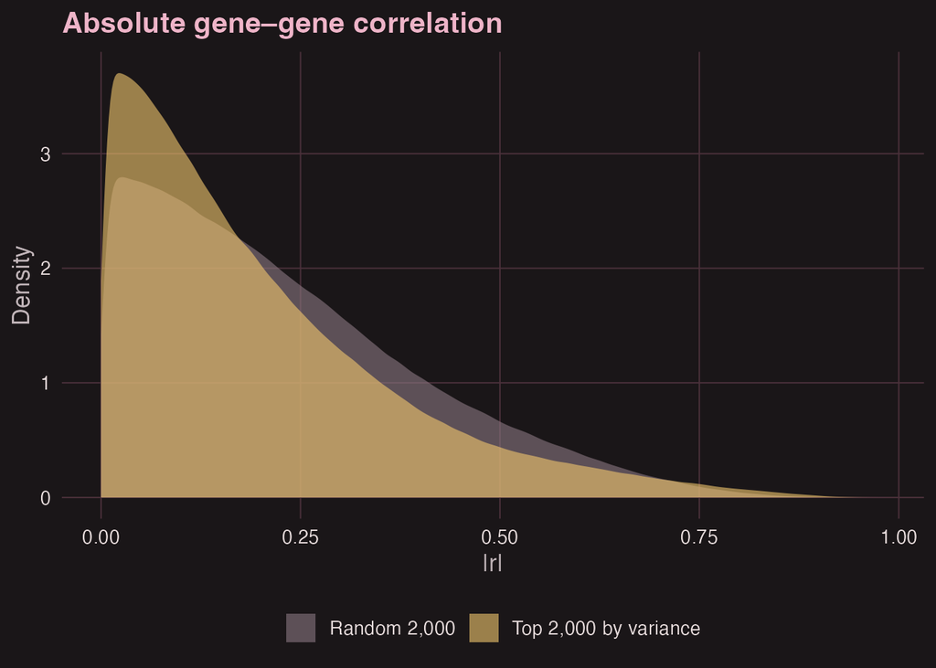

```r
ggplot(cor_cmp, aes(r, fill = set)) +
  geom_density(alpha = 0.6, color = NA) +
  scale_fill_manual(values = c(pal$muted, pal$gold)) +
  labs(title = "Absolute gene–gene correlation", x = "|r|", y = "Density", fill = NULL)
```

```r
pc1 <- function(genes) prcomp(t(adjusted_matrix[genes, ]), scale. = TRUE)$x[, 1]
c(random_pc1_vs_neutrophils   = cor(pc1(random_genes), sample_info$neutrophils),
  selected_pc1_vs_neutrophils = cor(pc1(selected_genes), sample_info$neutrophils))
```

```
  random_pc1_vs_neutrophils selected_pc1_vs_neutrophils
                  0.7287346                  -0.5785571
```

1. Adjustment removes the female–male difference, so `XIST` loses most of its variance; it still varies between women and may stay in the top 2,000.
2. The random genes correlate **more**, and the first PC of **both** sets follows the neutrophil fraction (a PC’s sign is arbitrary, so read |r|). In whole blood, the mix of cell types moves thousands of genes up and down together. Strong correlation is not automatically interesting structure: ask what drives it. That cell-mix axis is also why the lithium contrast, which raises neutrophils, needs care.

# 4 A quick baseline: differential expression

DE is not the focus today, but it gives us something to compare the networks against at the end. One limma model, on all expressed genes and adjusted for sex and plate, answers two questions: **lithium** (on vs off, within bipolar disorder) and **diagnosis** (patients off lithium vs controls, so the drug does not leak into the disease contrast).

```r
group_factor <- factor(sample_info$treatment, levels = grp_levels)
design <- model.matrix(~ 0 + group_factor + sex + plate, data = sample_info)
colnames(design) <- make.names(sub("group_factor", "", colnames(design)))
contrasts <- limma::makeContrasts(lithium = Lithium - no.Lithium,
                                  diagnosis = no.Lithium - Control, levels = design)
fit <- limma::lmFit(expression_matrix, design)
fit <- limma::eBayes(limma::contrasts.fit(fit, contrasts), trend = TRUE)
limma_results <- limma::topTable(fit, coef = "lithium", number = Inf)       # BH
diagnosis_results <- limma::topTable(fit, coef = "diagnosis", number = Inf)
deg <- rownames(limma_results)[limma_results$adj.P.Val < 0.05]   # lithium DEGs
```

**TipExercise 3 · How much of the DE signal reaches the network?**

How many genes pass FDR < 0.05 for lithium, and for diagnosis? How many of the 2,000 network genes are lithium DEGs?

```r
sum(limma_results$adj.P.Val < ___)
sum(___$adj.P.Val < 0.05)
sum(selected_genes %in% ___)
```

**NoteShow solution**

```r
c(lithium_fdr_0.05 = length(deg),
  diagnosis_fdr_0.05 = sum(diagnosis_results$adj.P.Val < 0.05),
  degs_in_network = sum(selected_genes %in% deg))
```

```
  lithium_fdr_0.05 diagnosis_fdr_0.05    degs_in_network
              4958                495                560
```

Thousands of genes pass FDR for lithium, mostly with small fold changes: with 338 samples, small shifts are detectable. The diagnosis contrast finds fewer. DEGs are **under-represented** among the most variable genes (28% of the network genes vs 38% genome-wide): in blood, variance is dominated by differences between people (HLA genotype, cell mix), not by lithium. We come back to this overlap at the end.

# 5 WGCNA

Now the first network. WGCNA builds **one** signed network from all 338 samples and groups the 2,000 genes into modules. The groups come back in only afterwards, when we ask which module eigengene follows lithium.

```r
invisible(capture.output(power_fit <- WGCNA::pickSoftThreshold(
  dat_expr, powerVector = c(1:10, seq(12, 20, 2)), networkType = "signed", verbose = 0)))
soft_power <- power_fit$powerEstimate   # lowest power with scale-free R^2 >= 0.85
soft_power
```

```
[1] 12
```

```r
wgcna_fit <- WGCNA::blockwiseModules(
  dat_expr, power = soft_power, networkType = "signed", TOMType = "signed",
  minModuleSize = 20, mergeCutHeight = 0.25, maxBlockSize = 5000,
  randomSeed = 20261109, verbose = 0
)
module_colors <- as.character(wgcna_fit$colors)  # already colour names
names(module_colors) <- colnames(dat_expr)
module_eigengenes <- WGCNA::orderMEs(wgcna_fit$MEs)
table(module_colors)
```

```
module_colors
      black        blue       brown       green greenyellow        grey
        112         334         255         143          30         172
    magenta        pink      purple         red         tan   turquoise
         80          84          38         116          26         426
     yellow
        184
```

**TipExercise 4 · Sensitivity to the soft threshold**

Re-run WGCNA with `power = 6`, below the scale-free plateau. How many modules do you get, and how large is the grey (unassigned) group? What does a lower power do to weak links?

```r
fit6 <- WGCNA::blockwiseModules(
  dat_expr, power = ___, networkType = "signed", TOMType = "signed",
  minModuleSize = 20, mergeCutHeight = 0.25, maxBlockSize = 5000,
  randomSeed = 20261109, verbose = 0
)
table(as.character(fit6$colors))
```

**NoteShow solution**

```r
fit6 <- WGCNA::blockwiseModules(
  dat_expr, power = 6, networkType = "signed", TOMType = "signed",
  minModuleSize = 20, mergeCutHeight = 0.25, maxBlockSize = 5000,
  randomSeed = 20261109, verbose = 0
)
cmp <- tibble(
  power = c(soft_power, 6),
  modules = c(length(setdiff(unique(module_colors), "grey")),
              length(setdiff(unique(as.character(fit6$colors)), "grey"))),
  grey_genes = c(sum(module_colors == "grey"),
                 sum(as.character(fit6$colors) == "grey"))
)
cmp
```

```
# A tibble: 2 × 3
  power modules grey_genes
  <dbl>   <int>      <int>
1    12      12        172
2     6      10        231
```

The power changes the partition: here β = 6 gives 10 modules and 231 grey genes, against 12 and 172 at β = 12. A lower power keeps more weak correlations, so the topological overlap is flatter and branch boundaries in the tree shift. Where one module ends and the next begins is partly your choice, so report the power you used.

**TipExercise 5 · Module–trait association and hubs**

Which module eigengene correlates most strongly with lithium treatment? List its 10 genes with the highest module membership (kME).

```r
case_indicator <- as.numeric(sample_info$treatment == "Lithium")
module_trait <- cor(module_eigengenes, ___)
mt <- module_trait[rownames(module_trait) != "MEgrey", , drop = FALSE]  # skip unassigned
top_module <- rownames(mt)[which.max(abs(mt[, 1]))]
kme <- WGCNA::signedKME(dat_expr, module_eigengenes)
top_color <- sub("^ME", "", top_module)
in_mod <- module_colors == top_color
kme_mod <- setNames(kme[[paste0("kME", ___)]], rownames(kme))[in_mod]
head(sort(kme_mod, decreasing = TRUE), 10)
```

**NoteShow solution**

```r
case_indicator <- as.numeric(sample_info$treatment == "Lithium")
module_trait <- cor(module_eigengenes, case_indicator)
module_trait[order(-abs(module_trait[, 1])), , drop = FALSE]
```

```
                     [,1]
MEblack        0.28073529
MEred         -0.27925446
MEturquoise   -0.24601277
MEgrey        -0.23475361
MEbrown        0.19081644
MEtan          0.17492191
MEgreen       -0.15289198
MEyellow       0.06906328
MEblue         0.06800188
MEpurple      -0.06238656
MEpink        -0.02462908
MEmagenta      0.01589772
MEgreenyellow  0.01337418
```

```r
mt <- module_trait[rownames(module_trait) != "MEgrey", , drop = FALSE]  # skip unassigned
top_module <- rownames(mt)[which.max(abs(mt[, 1]))]
kme <- WGCNA::signedKME(dat_expr, module_eigengenes)
top_color <- sub("^ME", "", top_module)
in_mod <- module_colors == top_color
kme_mod <- setNames(kme[[paste0("kME", top_color)]], rownames(kme))[in_mod]
hubs <- head(sort(kme_mod, decreasing = TRUE), 10)
tibble(gene = names(hubs), kME = round(hubs, 3))
```

```
# A tibble: 10 × 2
   gene       kME
   <chr>    <dbl>
 1 RNF24    0.943
 2 KDM6B    0.942
 3 PXN      0.938
 4 NOTCH1   0.937
 5 FMNL1    0.921
 6 GAB2     0.915
 7 RASGRP4  0.915
 8 KMT2D    0.902
 9 C15orf39 0.901
10 NBEAL2   0.901
```

These intramodular hubs are the genes that best represent the module’s expression pattern. They are the first genes to follow up, but being central does not make a gene a regulator.

# 6 ARACNE

WGCNA keeps every link and weights it. ARACNE does the opposite: it scores each pair by mutual information and then removes the links that look indirect, leaving a sparse network. Same 2,000 genes, same samples, a different idea of what a link is.

```r
mi_matrix <- minet::build.mim(dat_expr, estimator = "spearman")
aracne_matrix <- minet::aracne(mi_matrix, eps = 0)
aracne_degree <- rowSums(aracne_matrix > 0)
c(edges = sum(aracne_matrix > 0) / 2)
```

```
edges
 2685
```

**TipExercise 6 · Do ARACNE hubs and WGCNA hubs agree?**

Take the 50 genes with the highest ARACNE degree. Which WGCNA modules do they belong to? How many of the trait-associated module’s top-50 kME genes are also ARACNE hubs?

```r
aracne_hubs <- names(sort(aracne_degree, decreasing = TRUE))[1:___]
table(module_colors[aracne_hubs])
kme_top50 <- names(head(sort(kme_mod, decreasing = TRUE), 50))  # whole module if smaller
length(intersect(___, ___))
```

**NoteShow solution**

```r
aracne_hubs <- names(sort(aracne_degree, decreasing = TRUE))[1:50]
table(module_colors[aracne_hubs])
```

```
    black      blue     brown     green      grey   magenta       red       tan
        4        12         6         3         4         3         2         1
turquoise    yellow
       11         4
```

```r
kme_top50 <- names(head(sort(kme_mod, decreasing = TRUE), 50))  # whole module if smaller
length(intersect(aracne_hubs, kme_top50))
```

```
[1] 4
```

Here 4 genes are hubs in both. The two methods define importance differently: a WGCNA hub sits at the centre of one module, while ARACNE’s pruning removes indirect links, so its hubs are genes with many **direct**, non-redundant partners, often bridging modules (look at the module table above). Little overlap is common; genes found by both are the more robust candidates.

# 7 wTO networks per group

So far we have built one network for everybody. To see what lithium changes, we need one network **per group**, and a link score that keeps its sign, so that a pair going up together can be told apart from a pair moving in opposite directions. wTO is computed **separately** for each group (controls, patients off lithium, patients on lithium) on all 2,000 genes with 100 bootstrap resamples. The p-value measures stability: the share of resamples in which a link moved by more than `delta = 0.2`.

```r
wto_nets <- load_wto_networks(network_matrix, sample_info, n = 100)
sapply(wto_nets[c("control", "no_lithium", "lithium")],
       function(x) sum(x$pval.adj < 0.05))   # stable links per group
```

```
   control no_lithium    lithium
   1868928    1244632    1955501
```

```r
head(wto_nets$lithium)
```

```
     Node.1   Node.2    wTO  pval pval.adj
     <char>   <char>  <num> <num>    <num>
1: HLA-DQB1 HLA-DQA1  0.123     0        0
2: HLA-DQB1 HLA-DRB1  0.077     0        0
3: HLA-DQA1 HLA-DRB1  0.113     0        0
4: HLA-DQB1    HLA-A  0.005     0        0
5: HLA-DQA1    HLA-A -0.007     0        0
6: HLA-DRB1    HLA-A  0.000     0        0
```

**TipExercise 7 · Strongest links and sign flips**

List the 10 strongest links (largest |wTO|) among stable links (`pval.adj < 0.05`) in the control and in the lithium network. How many pairs are stable in both but have opposite signs?

```r
stable <- function(x) x[x$pval.adj < ___, ]
stable(wto_nets$control) |> arrange(desc(abs(wTO))) |> head(10)
both <- inner_join(stable(wto_nets$control), stable(wto_nets$lithium),
                   by = c("Node.1", "Node.2"), suffix = c(".ctrl", ".li"))
sum(sign(both$wTO.ctrl) != sign(___))
```

**NoteShow solution**

```r
stable <- function(x) x[x$pval.adj < 0.05, ]
stable(wto_nets$control) |> arrange(desc(abs(wTO))) |> head(10)
```

```
    Node.1 Node.2   wTO  pval pval.adj
    <char> <char> <num> <num>    <num>
 1:  RPL11  ZNF22 0.499     0        0
 2:  ZNF22 NDUFA5 0.497     0        0
 3:  ZNF22 ZNF761 0.497     0        0
 4:   CD69  ZNF22 0.496     0        0
 5:  ZNF22 ZNF181 0.496     0        0
 6: ZNF525  ZNF22 0.495     0        0
 7:  ZNF22   SNX4 0.495     0        0
 8:  ZNF22 ZNF480 0.495     0        0
 9:  ZNF22  UQCRB 0.495     0        0
10:  ZNF22 ZNF583 0.495     0        0
```

```r
stable(wto_nets$lithium) |> arrange(desc(abs(wTO))) |> head(10)
```

```
     Node.1  Node.2   wTO  pval pval.adj
     <char>  <char> <num> <num>    <num>
 1:   ZNF22    SNX4 0.477     0        0
 2: ZCCHC10   ZNF22 0.473     0        0
 3:  GIMAP2   ZNF22 0.473     0        0
 4:   ZNF22   TMCO1 0.473     0        0
 5:  RPL7P1   ZNF22 0.472     0        0
 6:   ETAA1   ZNF22 0.472     0        0
 7:   ZNF22  NDUFA5 0.472     0        0
 8:  RPL7P1 RSL24D1 0.471     0        0
 9:  RPL7P9 RSL24D1 0.471     0        0
10:  MRPL47   ZNF22 0.471     0        0
```

```r
both <- inner_join(stable(wto_nets$control), stable(wto_nets$lithium),
                   by = c("Node.1", "Node.2"), suffix = c(".ctrl", ".li"))
c(stable_in_both = nrow(both),
  sign_flips = sum(sign(both$wTO.ctrl) != sign(both$wTO.li)))
```

```
stable_in_both     sign_flips
       1854065         279219
```

Sign flips are the raw material of CoDiNA’s **β** class. Lithium was not randomized, so treat them as hypotheses.

# 8 Consensus network

A consensus asks which links are **robust across related networks**. Patients off and on lithium share the disease and differ in treatment, so their consensus is a **bipolar-disorder network** that does not depend on lithium.

```r
as_wto_input <- function(x) data.frame(Node.1 = factor(x$Node.1), Node.2 = factor(x$Node.2),
                                       wTO = x$wTO, pval = x$pval)
consensus <- wTO::wTO.Consensus(list(as_wto_input(wto_nets$no_lithium),
                                     as_wto_input(wto_nets$lithium)))
head(consensus)
```

```
    Node.1   Node.2        CN pval.fisher
1 HLA-DQB1 HLA-DQA1 0.1147105           0
2 HLA-DQB1 HLA-DRB1 0.0770000           0
3 HLA-DQA1 HLA-DRB1 0.1232367           0
4 HLA-DQB1    HLA-A 0.0010000           0
5 HLA-DQA1    HLA-A 0.0000000           0
6 HLA-DRB1    HLA-A 0.0360000           0
```

**TipExercise 8 · The bipolar consensus**

Keep links with |CN| ≥ 0.3 and a BH-adjusted Fisher p < 0.05 (on 2,000 genes, wTO rarely exceeds 0.4). How many are there? How many of them are **strong (|ω| ≥ 0.3) and same-signed in both** patient groups, and how many are carried by only one?

```r
robust <- consensus |>
  mutate(padj = p.adjust(pval.fisher, "BH")) |>
  filter(abs(CN) >= ___, padj < ___)
ab <- inner_join(wto_nets$no_lithium, wto_nets$lithium,
                 by = c("Node.1", "Node.2"), suffix = c(".off", ".on")) |>
  semi_join(robust |> mutate(across(c(Node.1, Node.2), as.character)),
            by = c("Node.1", "Node.2"))
table(agrees = sign(ab$wTO.off) == sign(ab$wTO.on) &
        pmin(abs(ab$wTO.off), abs(ab$wTO.on)) >= ___)
```

**NoteShow solution**

```r
robust <- consensus |>
  mutate(padj = p.adjust(pval.fisher, "BH")) |>
  filter(abs(CN) >= 0.3, padj < 0.05)
nrow(robust)
```

```
[1] 275044
```

```r
ab <- inner_join(wto_nets$no_lithium, wto_nets$lithium,
                 by = c("Node.1", "Node.2"), suffix = c(".off", ".on")) |>
  semi_join(robust |> mutate(across(c(Node.1, Node.2), as.character)),
            by = c("Node.1", "Node.2")) |>
  mutate(agrees = sign(wTO.off) == sign(wTO.on) & pmin(abs(wTO.off), abs(wTO.on)) >= 0.3)
table(ab$agrees)
```

```
 FALSE   TRUE
 86871 188173
```

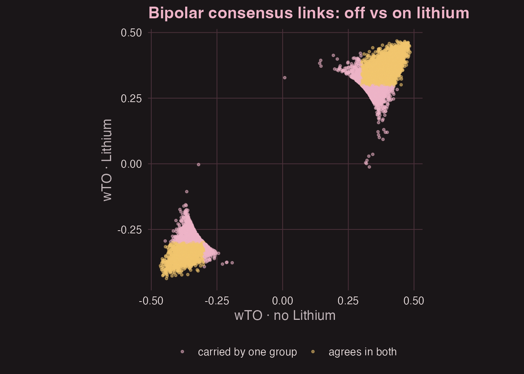

```r
set.seed(3)
ggplot(ab |> slice_sample(n = min(8000, nrow(ab))), aes(wTO.off, wTO.on, color = agrees)) +
  geom_point(alpha = 0.5, size = 0.8) +
  scale_color_manual(values = c(`FALSE` = pal$rose, `TRUE` = pal$gold),
                     labels = c("carried by one group", "agrees in both")) +
  coord_equal() +
  labs(title = "Bipolar consensus links: off vs on lithium",
       x = "wTO · no Lithium", y = "wTO · Lithium", color = NULL)
```

Weighting by |ω| lets the stronger network dominate: a link that is strong in one group and weak in the other still gets a large CN and a small Fisher p. So look at each network before calling a link shared. The links that agree form the shared bipolar network; the ones carried by one group are where CoDiNA looks for treatment effects.

# 9 CoDiNA

The consensus kept what the two patient groups share. CoDiNA looks at all three groups at once and asks what is **different**. With three networks, every link is a point in the cube $[-1,1]^3$ and its class says **where** it is present: `g.noLithium.Lithium` = both patient groups but not controls (disease), `g.Lithium` = only on lithium, and so on.

```r
to_codina <- function(x, padj = 0.05) {
  x |> filter(pval.adj < padj) |> transmute(Node.1, Node.2, wTO)
}
codina_input <- lapply(wto_nets[c("control", "no_lithium", "lithium")], to_codina)
codes <- c("Control", "noLithium", "Lithium")
codina_result <- CoDiNA::MakeDiffNet(Data = codina_input, Code = codes,
                                     cutoff = 0.33, stretch = TRUE)
sort(table(codina_result$Phi_tilde), decreasing = TRUE)
```

```
                  a   g.Control.Lithium           g.Lithium g.noLithium.Lithium
             484941              164255              147171              112864
        g.noLithium           g.Control g.Control.noLithium b.noLithium.Lithium
             111694              101222               42568                  16
        b.noLithium
                  4
```

**TipExercise 9 · Why stretch?**

The three networks come from 112, 74 and 152 samples. Compare their |wTO| distributions, then re-run `MakeDiffNet()` with `stretch = FALSE`. How do the γ classes change, and why?

```r
sapply(wto_nets[c("control", "no_lithium", "lithium")],
       function(x) quantile(abs(x$wTO), ___))
codina_raw <- CoDiNA::MakeDiffNet(Data = codina_input, Code = codes,
                                  cutoff = 0.33, stretch = ___)
sort(table(codina_raw$Phi_tilde), decreasing = TRUE)
```

**NoteShow solution**

```r
sapply(wto_nets[c("control", "no_lithium", "lithium")],
       function(x) quantile(abs(x$wTO), c(0.5, 0.9, 0.99)))
```

```
    control no_lithium lithium
50%   0.138      0.166   0.145
90%   0.311      0.341   0.308
99%   0.428      0.433   0.408
```

```r
codina_raw <- CoDiNA::MakeDiffNet(Data = codina_input, Code = codes,
                                  cutoff = 0.33, stretch = FALSE)
full_join(as.data.frame(table(Phi_tilde = codina_result$Phi_tilde)),
          as.data.frame(table(Phi_tilde = codina_raw$Phi_tilde)),
          by = "Phi_tilde", suffix = c(".stretch", ".raw"))
```

```
            Phi_tilde Freq.stretch Freq.raw
1                   a       484941    90802
2         b.noLithium            4       NA
3 b.noLithium.Lithium           16       NA
4           g.Control       101222    24664
5   g.Control.Lithium       164255    13639
6 g.Control.noLithium        42568    22926
7           g.Lithium       147171    13091
8         g.noLithium       111694    87739
9 g.noLithium.Lithium       112864    19994
```

The networks do not share one scale: the 74-patient network sits highest across its whole |wTO| distribution. On the raw scale, links cross the 0.33 threshold most often in that group, so the γ links pile up in `g.noLithium` and most other classes shrink. `stretch = TRUE` rescales each network by its own maximum |wTO| before discretizing. Group size is one reason for the different scales (correlations from fewer samples are noisier, and noise inflates |r|); real differences in co-expression are another. A stricter check is to subsample every group to the same size and rebuild the networks.

**TipExercise 10 · From links to genes**

Use `ClusterNodes()` to assign genes to CoDiNA classes. Which genes are **disease** genes (`g.noLithium.Lithium`) and which are **lithium-only** (`g.Lithium`)?

```r
codina_nodes <- CoDiNA::ClusterNodes(codina_result, cutoff.external = ___,
                                     cutoff.internal = ___)
table(codina_nodes$Phi_tilde)
disease_genes <- codina_nodes$Node[codina_nodes$Phi_tilde == ___]
case_genes <- codina_nodes$Node[codina_nodes$Phi_tilde == ___]
```

**NoteShow solution**

```r
codina_nodes <- CoDiNA::ClusterNodes(codina_result, cutoff.external = 0,
                                     cutoff.internal = 1)
sort(table(codina_nodes$Phi_tilde), decreasing = TRUE)
```

```
                  a   g.Control.Lithium           g.Lithium           g.Control
               1396                 186                 168                  95
        g.noLithium g.noLithium.Lithium g.Control.noLithium
                 94                  57                   4
```

```r
disease_genes <- as.character(codina_nodes$Node[codina_nodes$Phi_tilde == "g.noLithium.Lithium"])
case_genes <- as.character(codina_nodes$Node[codina_nodes$Phi_tilde == "g.Lithium"])
c(disease = length(disease_genes), lithium_only = length(case_genes))
```

```
     disease lithium_only
          57          168
```

```r
head(disease_genes, 15)
```

```
 [1] "ADISSP"    "ALDH2"     "ATP9A"     "BUB1"      "C14orf132" "CAPN12"
 [7] "CCN3"      "CD14"      "CPT1A"     "CTSW"      "DCBLD1"    "ERBB2"
[13] "FAT4"      "FCN1"      "FCRL5"
```

`ClusterNodes()` counts each gene’s links per class and keeps the class only when a chi-square test says the links concentrate there (BH < 0.05); otherwise the gene is “U” (unclassified). Disease genes are connected in **both** patient groups but not in controls, so lithium cannot explain them; lithium-only genes gain partners only in treated patients.

# 10 Functional enrichment

We now have several gene lists: modules, hubs, disease genes, and lithium-only genes. Enrichment asks what these genes might be doing. The answer depends a lot on what you compare them against.

**TipExercise 11 · The background matters**

Run GO Biological Process ORA on the lithium-only (`g.Lithium`) genes twice: once with the 2,000 network genes as universe, once without a universe (whole annotated genome). Compare the number of terms with FDR < 0.05.

```r
to_entrez <- function(symbols) clusterProfiler::bitr(
  symbols, fromType = "SYMBOL", toType = "ENTREZID", OrgDb = org.Hs.eg.db::org.Hs.eg.db)
ora <- function(genes, universe = NULL) clusterProfiler::enrichGO(
  gene = unique(to_entrez(genes)$ENTREZID),
  universe = if (is.null(universe)) NULL else unique(to_entrez(universe)$ENTREZID),
  OrgDb = org.Hs.eg.db::org.Hs.eg.db, keyType = "ENTREZID", ont = "BP",
  pAdjustMethod = "BH", pvalueCutoff = 1, qvalueCutoff = 1)
sum(as.data.frame(ora(case_genes, ___))$p.adjust < 0.05)
sum(as.data.frame(ora(case_genes))$p.adjust < 0.05)
```

**NoteShow solution**

```r
to_entrez <- function(symbols) clusterProfiler::bitr(
  symbols, fromType = "SYMBOL", toType = "ENTREZID", OrgDb = org.Hs.eg.db::org.Hs.eg.db)
ora <- function(genes, universe = NULL) clusterProfiler::enrichGO(
  gene = unique(to_entrez(genes)$ENTREZID),
  universe = if (is.null(universe)) NULL else unique(to_entrez(universe)$ENTREZID),
  OrgDb = org.Hs.eg.db::org.Hs.eg.db, keyType = "ENTREZID", ont = "BP",
  pAdjustMethod = "BH", pvalueCutoff = 1, qvalueCutoff = 1)
ora_universe <- ora(case_genes, selected_genes)
ora_genome <- ora(case_genes)
c(network_universe = sum(as.data.frame(ora_universe)$p.adjust < 0.05),
  whole_genome = sum(as.data.frame(ora_genome)$p.adjust < 0.05))
```

```
network_universe     whole_genome
               0                0
```

```r
head(as.data.frame(ora_universe)[, c("Description", "GeneRatio", "p.adjust")], 10)
```

```
                                   Description GeneRatio  p.adjust
GO:0008015                   blood circulation    12/147 0.9998169
GO:0003008                      system process    26/147 0.9998169
GO:0003013          circulatory system process    14/147 0.9998169
GO:0070371               ERK1 and ERK2 cascade     9/147 0.9998169
GO:0002377           immunoglobulin production     5/147 0.9998169
GO:0002088 lens development in camera-type eye     4/147 0.9998169
GO:0003014                renal system process     5/147 0.9998169
GO:0019731      antibacterial humoral response     5/147 0.9998169
GO:0002250            adaptive immune response    18/147 0.9998169
GO:0006897                         endocytosis    17/147 0.9998169
```

The two runs ask different questions. Against the 2,000 network genes: are the `g.Lithium` genes special **among variable blood genes**? Against the whole genome: are they special **among all annotated genes**? The genome background adds thousands of genes and tests, so terms can appear or disappear in either direction. Whichever you choose, report it.

**TipExercise 12 · GSEA on module membership**

Rank all 2,000 genes by kME for the trait-associated module and run `gseGO()`. Which terms have the largest positive NES?

```r
rank_vec <- sort(setNames(kme[, paste0("kME", ___)], rownames(kme)), decreasing = TRUE)
```

**NoteShow solution**

```r
rank_vec <- sort(setNames(kme[, paste0("kME", top_color)], rownames(kme)), decreasing = TRUE)
rank_map <- to_entrez(names(rank_vec))
rank_tbl <- tibble(SYMBOL = names(rank_vec), score = rank_vec) |>
  inner_join(rank_map, by = "SYMBOL") |> distinct(ENTREZID, .keep_all = TRUE)
gene_list <- sort(setNames(rank_tbl$score, rank_tbl$ENTREZID), decreasing = TRUE)
gsea <- clusterProfiler::gseGO(gene_list, OrgDb = org.Hs.eg.db::org.Hs.eg.db,
                               ont = "BP", keyType = "ENTREZID", pvalueCutoff = 0.05,
                               seed = TRUE, verbose = FALSE)
as.data.frame(gsea) |> arrange(desc(NES)) |>
  select(Description, setSize, NES, p.adjust) |> head(10)
```

```
                                        Description setSize      NES
GO:0009755       hormone-mediated signaling pathway      15 2.108196
GO:0001659                  temperature homeostasis      27 2.095849
GO:0098657                         import into cell     131 2.065833
GO:0030029             actin filament-based process      99 2.057619
GO:1990845                   adaptive thermogenesis      23 2.041058
GO:0010517     regulation of phospholipase activity      10 2.034460
GO:0030036          actin cytoskeleton organization      93 2.033557
GO:0060191            regulation of lipase activity      11 2.032219
GO:0030522 intracellular receptor signaling pathway      33 2.030655
GO:0106106               cold-induced thermogenesis      22 2.023475
               p.adjust
GO:0009755 3.337333e-03
GO:0001659 1.226330e-03
GO:0098657 3.735962e-05
GO:0030029 1.292341e-04
GO:1990845 4.013726e-03
GO:0010517 3.045958e-03
GO:0030036 3.349630e-04
GO:0060191 2.173216e-03
GO:0030522 1.379099e-03
GO:0106106 3.402883e-03
```

A positive NES means the term is concentrated among the genes most tied to the module. No cutoff was needed: GSEA used the whole ranking. Compare these terms with the hubs you listed in Exercise 5.

# 11 Comparing outcomes

We end where we started, with limma. Do the networks point at the same genes that changed their average expression, or at different ones?

**TipExercise 13 · Do DE and networks point at the same genes?**

For each of the 2,000 network genes, record whether it is a lithium **DEG** (FDR < 0.05), a **WGCNA hub** of the trait-associated module (top 50 kME), an **ARACNE hub** (top 50 degree), and **lithium-only** in CoDiNA (`g.Lithium`). How many genes are flagged by DE only, by a network method only, or by both? Then ask the disease question: how many CoDiNA disease genes (`g.noLithium.Lithium`) are **diagnosis** DEGs?

```r
flags <- tibble(gene = selected_genes) |>
  mutate(DEG = gene %in% ___,
         WGCNA_hub = gene %in% names(head(sort(kme_mod, decreasing = TRUE), 50)),
         ARACNE_hub = gene %in% aracne_hubs,
         CoDiNA_lithium = gene %in% ___)
flags |> mutate(network = WGCNA_hub | ARACNE_hub | CoDiNA_lithium) |> count(DEG, network)
```

**NoteShow solution**

```r
wgcna_hubs <- names(head(sort(kme_mod, decreasing = TRUE), 50))
flags <- tibble(gene = selected_genes) |>
  mutate(DEG = gene %in% deg,
         WGCNA_hub = gene %in% wgcna_hubs,
         ARACNE_hub = gene %in% aracne_hubs,
         CoDiNA_lithium = gene %in% case_genes)
flags |> mutate(network = WGCNA_hub | ARACNE_hub | CoDiNA_lithium) |> count(DEG, network)
```

```
# A tibble: 4 × 3
  DEG   network     n
  <lgl> <lgl>   <int>
1 FALSE FALSE    1258
2 FALSE TRUE      182
3 TRUE  FALSE     479
4 TRUE  TRUE       81
```

```r
# DEG rate inside each network gene set vs the 2,000-gene background
flags |>
  summarise(across(c(WGCNA_hub, ARACNE_hub, CoDiNA_lithium),
                   ~ mean(DEG[.x]), .names = "{.col}")) |>
  mutate(all_network_genes = mean(flags$DEG))
```

```
# A tibble: 1 × 4
  WGCNA_hub ARACNE_hub CoDiNA_lithium all_network_genes
      <dbl>      <dbl>          <dbl>             <dbl>
1      0.54       0.32          0.244              0.28
```

```r
flags |> filter(DEG, WGCNA_hub | CoDiNA_lithium) |> head(10)
```

```
# A tibble: 10 × 5
   gene     DEG   WGCNA_hub ARACNE_hub CoDiNA_lithium
   <chr>    <lgl> <lgl>     <lgl>      <lgl>
 1 ALOX15   TRUE  FALSE     FALSE      TRUE
 2 PLVAP    TRUE  FALSE     FALSE      TRUE
 3 MXRA7    TRUE  FALSE     FALSE      TRUE
 4 NSG1     TRUE  FALSE     FALSE      TRUE
 5 IDO1     TRUE  FALSE     FALSE      TRUE
 6 IGFBP3   TRUE  FALSE     FALSE      TRUE
 7 RUNDC3A  TRUE  FALSE     FALSE      TRUE
 8 EGF      TRUE  FALSE     FALSE      TRUE
 9 RN7SKP16 TRUE  TRUE      FALSE      FALSE
10 SPATA20  TRUE  FALSE     FALSE      TRUE
```

```r
# the disease question: CoDiNA disease genes vs diagnosis DEGs
dx_deg <- rownames(diagnosis_results)[diagnosis_results$adj.P.Val < 0.05]
c(disease_genes = length(disease_genes),
  also_diagnosis_DEG = sum(disease_genes %in% dx_deg),
  rate_disease_genes = mean(disease_genes %in% dx_deg),
  rate_all_network_genes = mean(selected_genes %in% dx_deg))
```

```
         disease_genes     also_diagnosis_DEG     rate_disease_genes
           57.00000000             1.00000000             0.01754386
rate_all_network_genes
            0.06250000
```

The methods answer different questions, so the lists overlap only partly. Genes flagged by **both** DE and a network method are the strongest candidates; network-only genes are where co-expression adds something DE cannot see.

# 12 Reflection

Back to the question we started with: what does lithium change, and what belongs to the disease? You now have several partial answers. Take a few minutes with these:

1. Which of your results would you trust enough to plan an experiment around, and which need an independent cohort first?
2. Name one parameter whose change altered your conclusions, and how you would report it.
3. Pick one gene that appears in several analyses (DE, WGCNA hub, ARACNE hub, CoDiNA class). What hypothesis would you test for it?

Questions after the workshop are welcome: deisy.gysi@ufpr.br · https://deisygysi.github.io/